# Genome wide plots of mC in 100 kbp bins, with moving average

Tomato TET3 BS-seq selected plants

Javier Antúnez Sánchez

December 2025

Analysis of DNA methylation in 100 kbp bins created with `CX_report2summary_v0.1.pl` from Bismark CX_reports.

# Data

I filter out the samples that contain less than 14 Million Cytosines covered (WT_6, A_1, A_12, B_6, B_11, B_5, B1_2, B2_14, B2_18 & B2_20) as outliers as explained in the bins PCA report.

## Scatter matrices

### WT CG

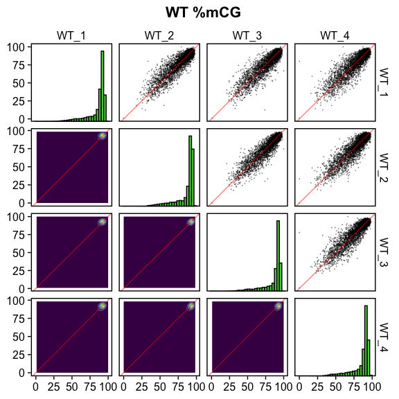

### WT CHG

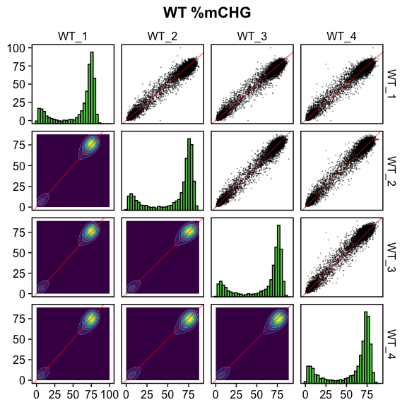

### WT CHH

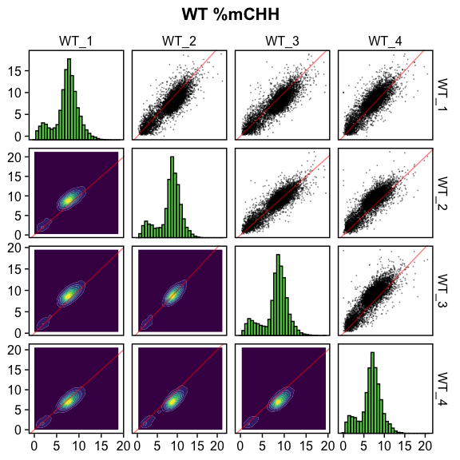

### A T1 CG

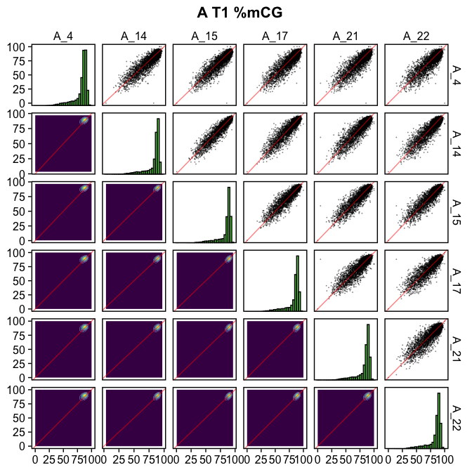

### A T2 CG

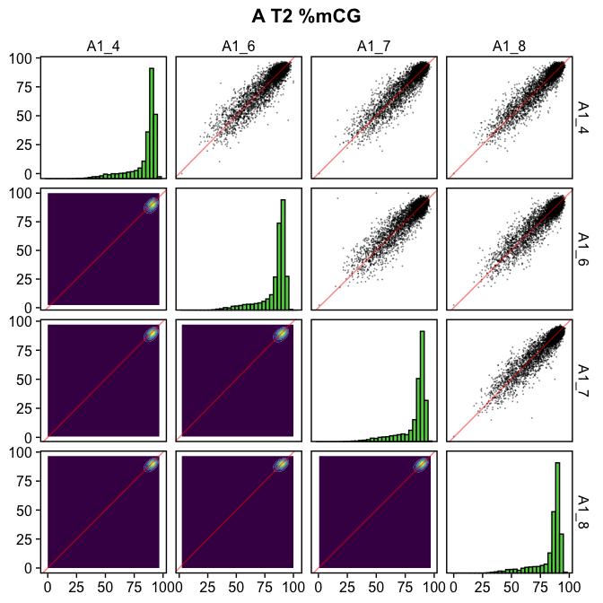

### A T3 CG

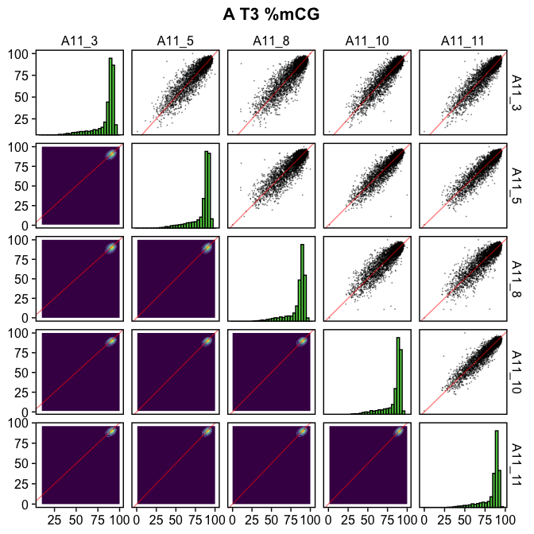

### B T1 CG

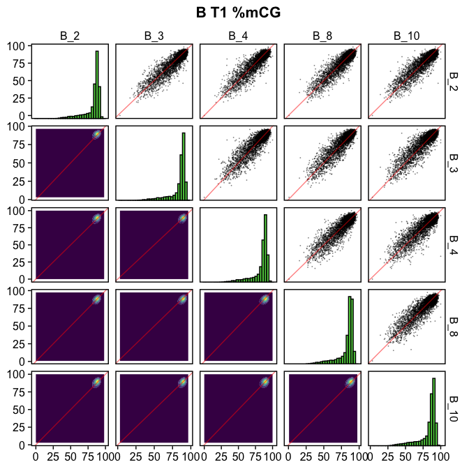

### B T2- CG

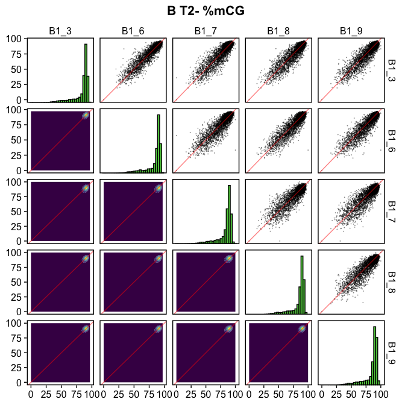

### B T2+ CG

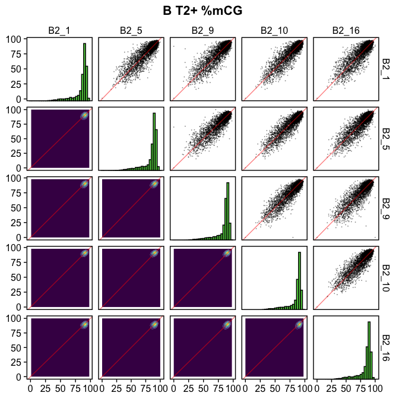

# Moving average

Function to generate sliding mean and median of methylation and methylation difference from a reference sample (renamed). It takes a wide table and produces a long table.

[output not shown]

Compute the sliding binned data for 21 bins (10 bins (1 Mb) to each side)

[output not shown]

Compute the sliding binned data for 101 bins (50 bins (5 Mb) to each side)

## some dispersion plot

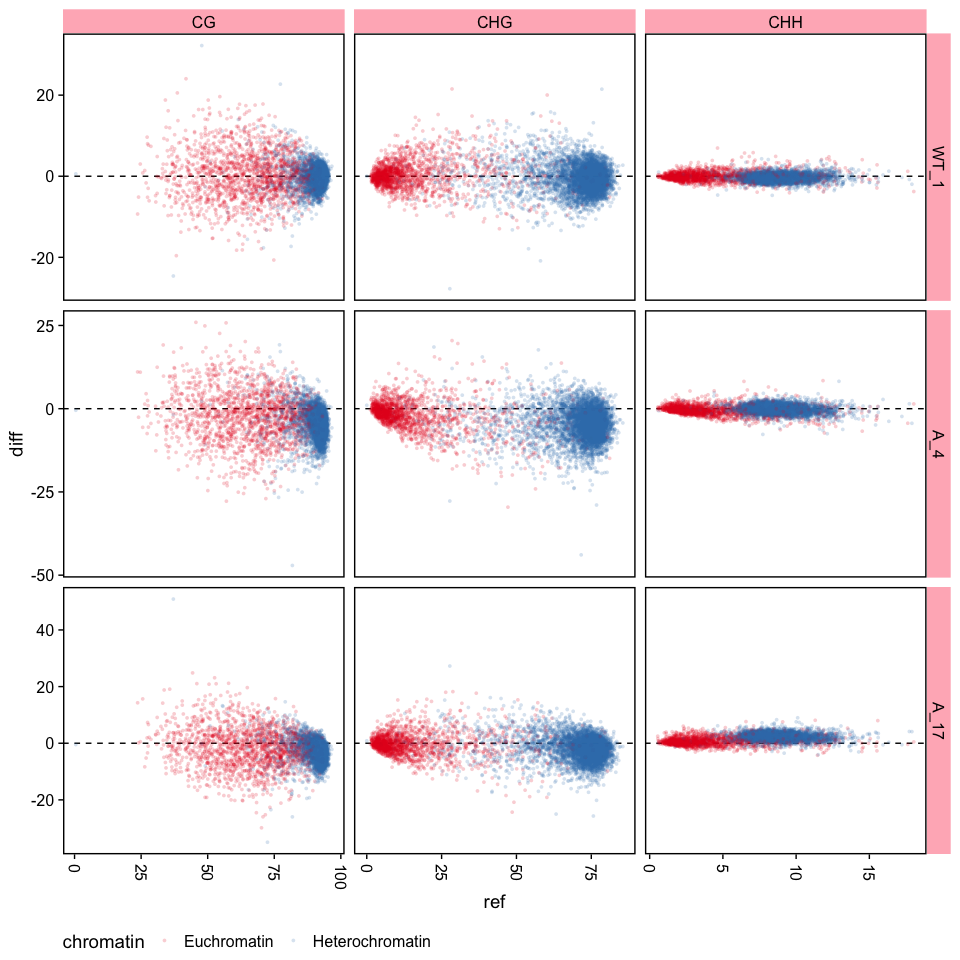

## Trellis plots

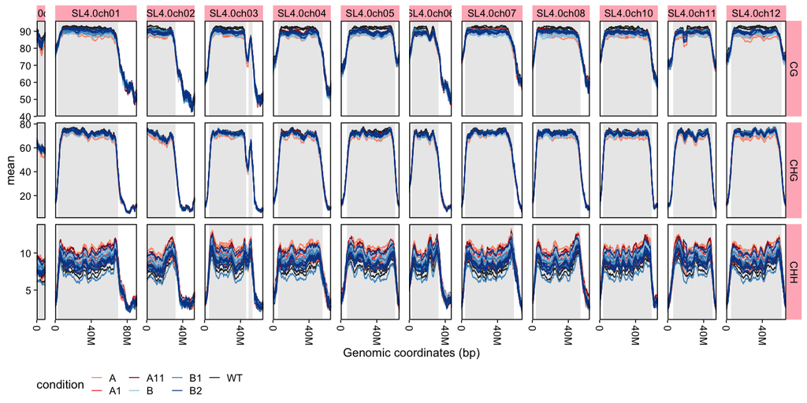

[figure not shown]

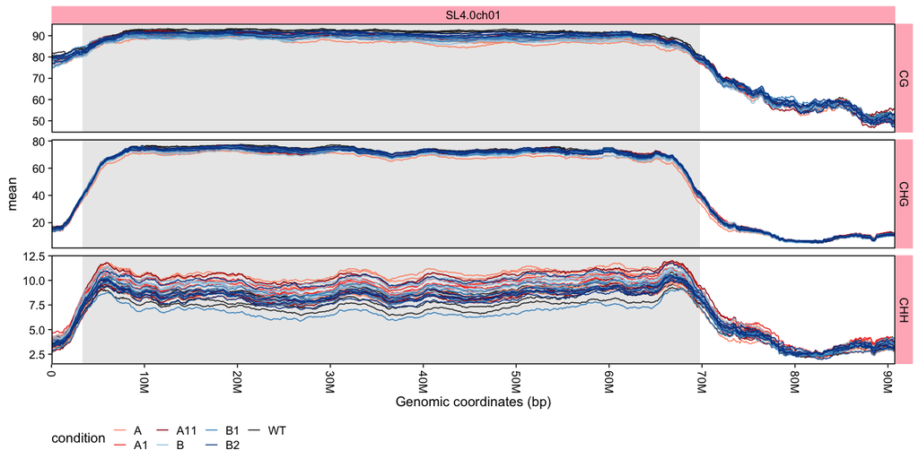

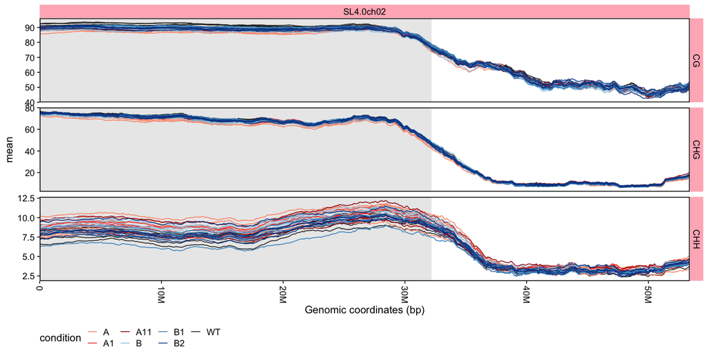

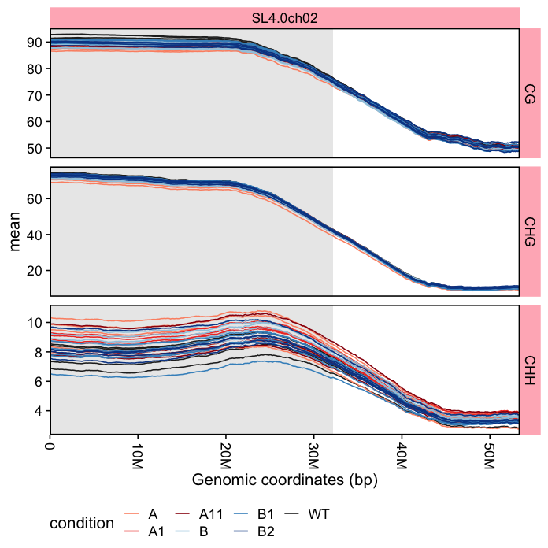

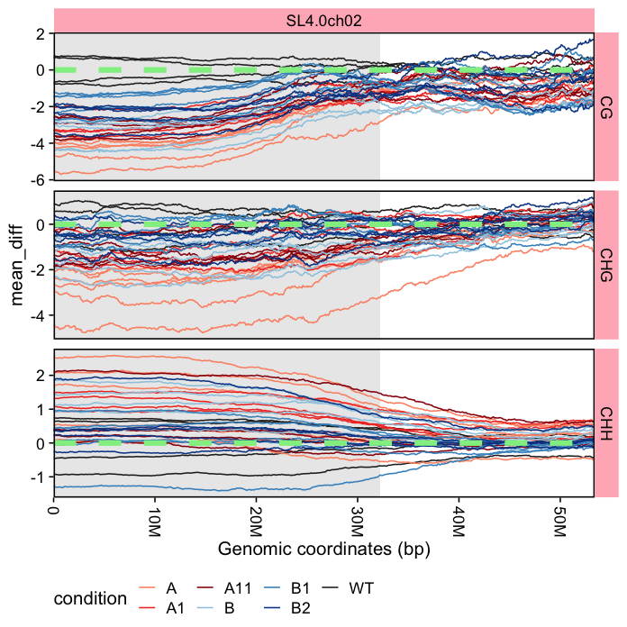

## Heatmap plots

[output not shown]

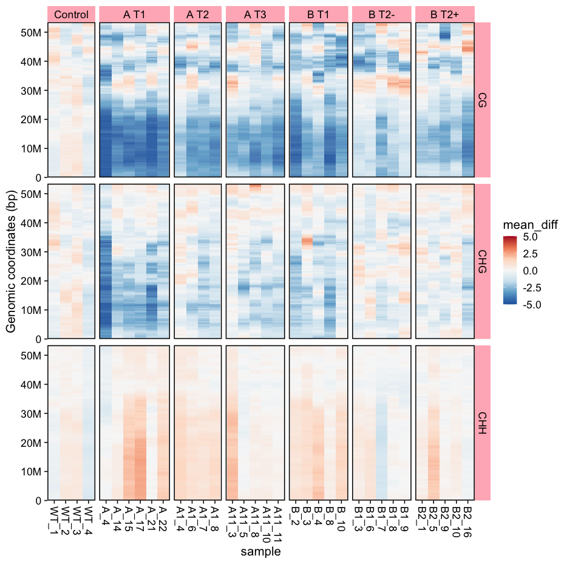

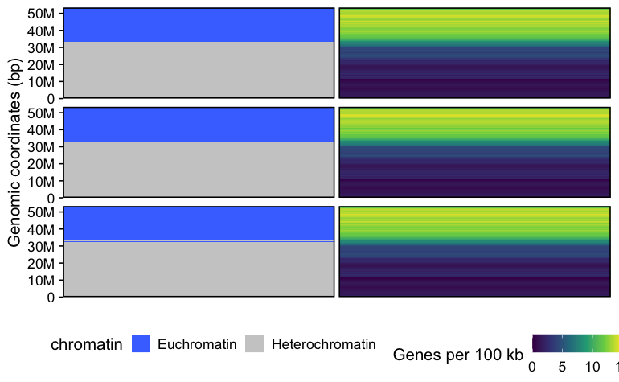

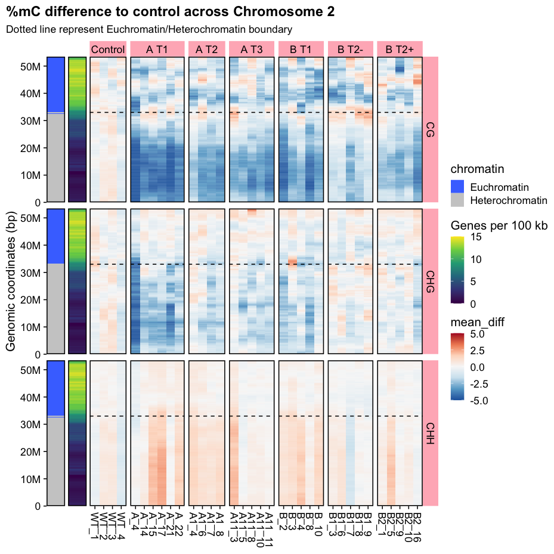

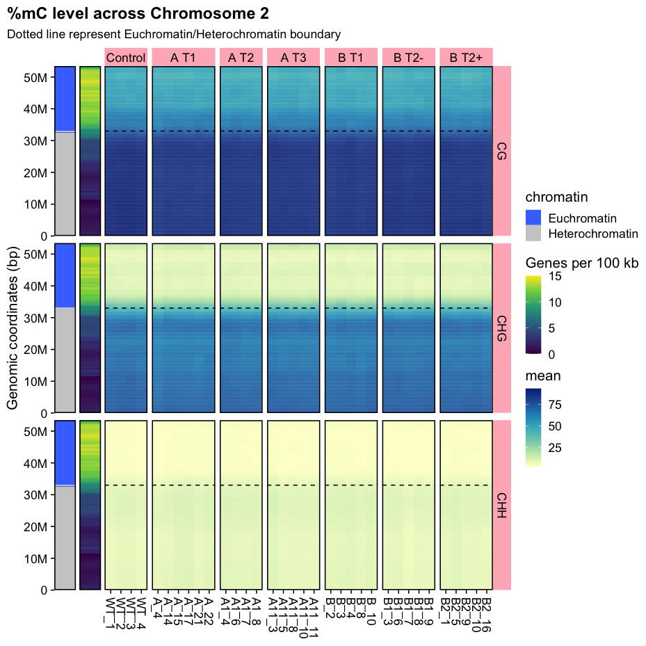